# Online Supplement 4: Response Time Mixture Model

- Show All Code
- Hide All Code
- View Source

For the Manuscript: Identifying Careless Responding in Ecological Momentary Assessment: Inconsistent Signals from Different Detection Methods in the WARN-D Data

Authors

Affiliations

Esther Ulitzsch

Centre for Educational Measurement, University of Oslo; Centre for Research on Equality in Education, University of Oslo

Gudrun Eisele

KU Leuven

Leonie V.D.E. Vogelsmeier

Tilburg University

Published

September 2, 2025

# 1 Background

In this script, we aimed to investigate careless responding using a timing-based mixture model. The model makes use of the time spent on a targeted segment of the EMA, which can either be the full survey or, in cases where the assessment involves branching or administering different items at different times of day, a specific block of items at each measurement occasion. The model distinguishes between unobserved response states (attentive versus careless) by assuming different data-generating processes for the time spent on the targeted segment. For attentive responses, time is assumed to be influenced by (a) a person-specific parameter that reflects the initial time a respondent requires when first encountering the items and (b) a person-specific parameter governing the speed-up due to habituation and practice, modeled with an exponential decay function. This function captures rapid gains at the beginning while gradually tapering off, with a lower bound to prevent unrealistically short times. Whether a person is attentive at a given measurement occasion is modeled using an IRT framework, where attentiveness is a function of the individual’s overall attentiveness and the occasion-specific difficulty of being attentive. These difficulties are allowed to vary linearly both within and across days. The method was proposed and evaluated in Ulitzsch, Nestler, et al. (2024). A brief summary of the method is presented in the main manuscript. Bayesian model estimation is conducted using `stan`. For a detailed technical description, please refer to the article in which the model was originally presented.

# 2 Preliminaries

We first install and load all relevant packages.

```r
if(!require(pacman)) install.packages("pacman")
pacman::p_load("ggplot2", "rstan", "ggh4x")
```

# 3 Data Preparation

This section outlines all relevant preprocessing steps for your analysis. Note that the data characteristics are outlined in the main manuscript. First, we load the data, retaining only the necessary information for this specific analysis due to its large size.

```r
# load the complete data
data <- read.csv(here::here("data","WARND_stage2_c1234_trainingset_before_15min_v2024_07_16.csv"))

# store indicator names for later (indicators 1:7 are NA, 8:10 are PA; we are interested in the associated response times)
indicators <- c("rt_sad_d", "rt_stressed_d", "rt_overwhelm_d", "rt_nervous_d", "rt_ruminate_d", "rt_irritable_d", "rt_tired_d", "rt_cheerful_d", "rt_motivated_d", "rt_relaxed_d")

# keep data for which we have responses on the PA and NA indicators
data <- data[complete.cases(data[,indicators]),]

# keep only data that we need
data <- data[,c("external_id", "record_time", "day_num", "prompt_num" , indicators)]
```

For the analysis, for each observation, we need (a) log total time spent on the 10 target items, (b) number of days passed since start of the EMA, (c) number of prompts received since the start of the day, and (d) number of prompts responded to since the start of the EMA.

```r
# (a) log total time spent on the 10 target items
data$first_response <- as.POSIXlt(apply(data[,indicators],1,min))
data$last_response <- as.POSIXlt(apply(data[,indicators],1,max))
data$log_total_time <- log(as.numeric(data$last_response-data$first_response)/60) # in minutes

# (b) number of days passed since start of the EMA -> in the data set (day_num)
# (c) number of prompts received since the start of the day -> in the data set (prompt_num)

# (d) number of prompts responded to since the start of the EMA
data <- data[order(data$external_id, data$day_num, data$prompt_num), ] # make sure that data are in the correct order
data$obs_id <- as.numeric(ave(data$external_id, data$external_id, FUN = seq_along)) # create obs_id within each subject
```

# 4 Descriptives

Next, we examine how log-transformed time spent on the 10 target items evolved over the course of the EMA. Inspecting the average trajectory, we observe an initial speed-up during the first week, which then levels off, likely reflecting the effects of practice and habituation.

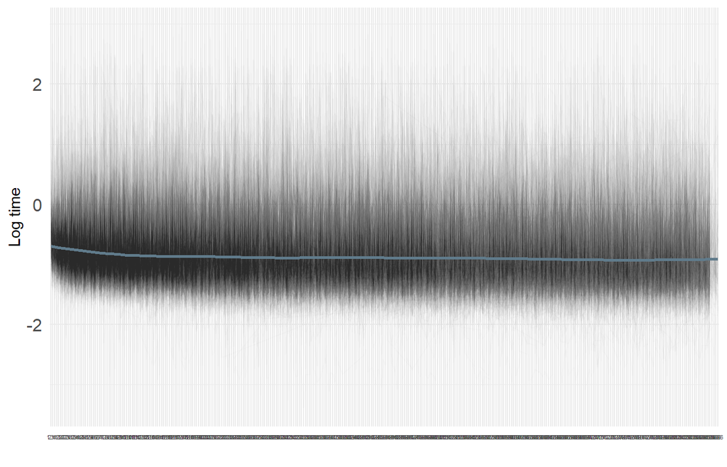

```r
p <- ggplot(data, aes(x = interaction(prompt_num, day_num),log_total_time))
p <- p + geom_line(aes(group = external_id), alpha = 0.01) + geom_smooth(aes(group = 1), color = "lightskyblue4", se = FALSE, method = "gam", linewidth = 1)
p <- p + theme_minimal() +
  theme(axis.text.x = element_text(size = 4),axis.text.y = element_text(size = 12))
p <- p + scale_x_discrete(guide = "axis_nested") + labs(y="Log time", x="")
p
```

# 5 Analysis

We use `stan` for Bayesian model estimation, using the following code.

```stan
data{
  int<lower = 1> N; // number of persons
  int<lower = 1> Nobs; // number of observations
  int<lower = 1> person[Nobs]; // person id
  int<lower = 1> obs_id[Nobs]; // number of prompts responded to since the start of the EMA
  int<lower = 1> prompt_num[Nobs]; // number of prompts received since the start of the day
  int<lower = 1> day_num[Nobs]; // number of days passed since start of the EMA
  real log_total_time[Nobs]; // log total time on the target segment
}
parameters{
  row_vector[3] PersPar[N]; // person parameters: 1: attentiveness, 2: log initial time expenditure, 3: log habitual decay
  real gamma0; // initial attentiveness difficulty
  real gammaD; // change of attentiveness difficulty across days
  real gammaB; // change of attentiveness difficulty within days (across prompts)
  corr_matrix[3] correlP; // correlations of person parameters
  real muC; // average careless log time
  real<lower=0> offsetA; // offset, capturing difference between average careless log time and lower bound of attentive times
  real muTau1; // mean of log initial time expenditure
  real muTau0; // mean of log habitual decay
  real<lower=0> sigmaC; // standard deviation of careless times
  real<lower=0> sigmaA; // residual standard deviation of attentive times
  vector<lower=0>[3] sigmaP; // sd person parameters
}
transformed parameters{
  real<lower=0,upper=1> pDelta[Nobs]; // attentiveness probabilities
  real eta[Nobs]; // argument for attentiveness probabilities logit
  cov_matrix[3] SigmaP; // person parameter variance covariance matrix
  SigmaP = quad_form_diag(correlP, sigmaP);
  for(n in 1:Nobs){
    eta[n]=PersPar[person[n],1] -(gamma0 + gammaD*(day_num[n]-1) + gammaB*(prompt_num[n]-1));
    pDelta[n] = 1/(1+exp(-eta[n]));
  }
}
model{
  // priors
  PersPar~ multi_normal(rep_vector(0,3),SigmaP);
  correlP ~ lkj_corr(1);
  sigmaP ~  cauchy(0,2);
  muTau0  ~  normal(0,5);
  muTau1  ~  normal(0,5);

  gamma0 ~ normal(0, 5);
  gammaD ~ normal(0, 5);
  gammaB ~ normal(0, 5);

  sigmaC ~  cauchy(0,2);
  sigmaA ~  cauchy(0,2);

  muC ~  normal(0,5);
  offsetA ~  normal(0,5);

  // model
  for(n in 1:Nobs) {
    target += log_mix(pDelta[n],
    normal_lpdf(log_total_time[n]|muC + offsetA + exp(PersPar[person[n],2]+muTau0)*(exp(PersPar[person[n],3]+muTau1))^(obs_id[n]-1), sigmaA), // attentive observation
    normal_lpdf(log_total_time[n]|muC, sigmaC));  // careless observation
  }
}
```

We first prepare a data list for `stan`, which includes all variables and constants specified in the data block of the model.

```r
dat_list <- list(
  N  = length(unique(data$external_id)), # number of respondents
  Nobs  = nrow(data), # number of observations
  person = as.numeric(as.factor(data$external_id)), # person id
  obs_id = data$obs_id, # number of prompts responded to since the start of the EMA
  day_num = data$day_num, # number of days passed since start of the EMA
  prompt_num = data$prompt_num, # number of prompts received since the start of the day
  log_total_time = data$log_total_time # log total time on the target segment
)
```

Next, we can pass the data list to `stan` and estimate the model.

```r
start <- Sys.time()
fitCare <- stan(file = 'screentimeCIER.stan',  data = dat_list, iter = 10000, chains = 2, thin = 10)
end <- Sys.time()
end-start
sumCare <- summary(fitCare)[[1]]

PSRF <- sumCare[,"Rhat"] # check convergence
max(PSRF, na.rm = T)
```

The model did not converge. This can be related to the complexity of the model or characteristics of the data. To explore the specific causes of the non-convergence, we can modify the model or use subsets of the data. However, We also did not achieve convergence in a smaller subset of the data, or by having attentiveness vary within days as a function of time of the day or the number of prompts issued (rather than responded to). This prevents us from drawing conclusions about the cause of non-convergence.